# EAS 508 Assignment 2– Sainath Aittla, UB ID: 50557807

```r
library(ISLR2)
library(ggplot2)
library(MASS)
library(car)
library(class)
library(corrplot)
```

In case you need to write math expression, please use the quick tutorial as the reference: https://www1.cmc.edu/pages/faculty/aaksoy/latex/latexthree.html

# Question 1 [5 points]

Describe a situation or problem from your job, everyday life, current events, etc., for which a logistic regression model would be appropriate. List some (up to 5) predictors that you might use.

Please show your work.

```
Answer:
```

A logistic regression model is well-suited for situations where you want to predict a binary outcome—essentially, where the outcome is either one thing or another, such as “yes” or “no”, “success” or “failure”, “present” or “absent”, etc. An example from the healthcare sector is predicting whether a patient has a particular disease (e.g., diabetes) based on various health indicators and lifestyle factors.

**Situation: Predicting the Onset of Diabetes**

**Problem Description:**

In this scenario, a healthcare provider wants to develop a predictive model to identify patients at high risk of developing Type 2 diabetes within the next five years. Early identification can lead to early intervention, which might include lifestyle coaching, targeted health education, and closer monitoring, potentially delaying or preventing the onset of diabetes.

**Predictors for the Logistic Regression Model:**

**Age:** Older individuals have a higher risk of developing Type 2 diabetes.

**Body Mass Index (BMI):** A higher BMI is associated with an increased risk of Type 2 diabetes.

**Family History of Diabetes:** Having a family member with diabetes increases the likelihood of developing the condition.

**Physical Activity Level:** Lower levels of physical activity are linked with a higher risk of Type 2 diabetes.

**Blood Pressure:** High blood pressure may be an indicator of an increased risk of Type 2 diabetes.

These predictors are chosen based on their known associations with the risk of developing Type 2 diabetes from existing medical literature and studies. The logistic regression model would be trained using historical patient data, where the outcome (whether or not the patient developed diabetes within a specified period) is known. This model could then be applied to current patients to estimate their risk based on the predictors listed. Such a model can be a valuable tool in preventative healthcare strategies.

# Question 2 [20 points]

In this problem, we will use the Naive Bayes algorithm to fit a spam filter by hand. This question does not involve any programming but only derivation and hand calculation. Spam filters are used in all email services to classify received emails as “Spam” or “Not Spam”. A simple approach involves maintaining a vocabulary of words that commonly occur in “Spam” emails and classifying an email as “Spam” if the number of words fromthe dictionary that are present in the email is over a certain threshold. We are given the vocabulary consists of 15 words

$$V = {\text{secret, offer, low, price,
valued, customer, today, dollar, million, sports, is, for, play,
healthy, pizza}}.$$

We will use $V_i$ to represent the $i$th word in $V$ . As our training dataset, we are also given 3 example spam messages,

- million dollar offer for today
- secret offer today
- secret is secret

and 4 example non-spam messages

- low price for valued customer
- play secret sports today
- sports is healthy
- low price pizza

Recall that the Naive Bayes classifier assumes the probability of an input depends on its input feature. The feature for each sample is defined as $x^{(i)}=[x^{(i)}_1, x^{(i)}_2,\cdots, x^{(i)}_p], i=1,\cdots,m$ and the class of the $i$th sample is $y^{(i)}$. In our case the length of the input vector is $p= 15$, which is equal to the number of words in the vocabulary $V$ (hint: recall that how did we define a dummy variable). Each entry $x^{(i)}_j$ is equal to the number of times word $V_j$ occurs in the $i$-th message.

1.[5 points] Calculate class prior $P(y = 0)$ and $P(y = 1)$ from the training data, where $y=0$ corresponds to spam messages, and $y=1$ corresponds to non-spam messages. Note that these class prior essentially corresponds to the frequency of each class in the training sample. Write down the predictor vectors for each spam and non-spam messages.

```
Answer:
```

We are given 3 spam messages and 4 non-spam messages in the training data.

**Class Prior for Spam p(y=0):** The probability of a message being spam,

P(y=0) = Number of Spam Messages/Total Number of Messages = **3/7**

**Class Prior for Spam p(y=1):** The probability of a message being non-spam,

P(y=1) = Number of Non-Spam Messages/Total Number of Messages = **4/7**

**Below are the predictor vectors**

**Spam Messages**

- million dollar offer for today

[0, 1, 0, 0, 0, 0, 1, 1, 1, 0, 0, 1, 0, 0, 0]

- secret offer today

[1, 1, 0, 0, 0, 0, 1, 0, 0, 0, 0, 0, 0, 0, 0]

- secret is secret

[2, 0, 0, 0, 0, 0, 0, 0, 0, 0, 1, 0, 0, 0, 0]

**Non-Spam Messages**

- low price for valued customer

[0, 0, 1, 1, 1, 1, 0, 0, 0, 0, 0, 1, 0, 0, 0]

- play secret sports today

[1, 0, 0, 0, 0, 0, 1, 0, 0, 1, 0, 0, 1, 0, 0]

- sports is healthy

[0, 0, 0, 0, 0, 0, 0, 0, 0, 1, 1, 0, 0, 1, 0]

- low price pizza

[0, 0, 1, 1, 0, 0, 0, 0, 0, 0, 0, 0, 0, 0, 1]

2. [15 points] In the Naive Bayes model, assuming the keywords are independent of each other (this is a simplification), the likelihood of a sentence with its feature vector $x$ given a class $c$ is given by
   $$P(x|y=c)=\prod_{i=1}^{15}P(x_i|y=c),
   c=\{0,1\}.$$

Given a test message “today is secret”, using the Naive Bayes classier to calculate the posterior and decide whether it is spam or not spam. Please show your work.

```
Answer:
```

|  | secret | offer | low | price | valued | customer | today | dollar | million | sports | is | for | play | healthy | pizza | Non-spam |
| --- | --- | --- | --- | --- | --- | --- | --- | --- | --- | --- | --- | --- | --- | --- | --- | --- |
| 1 | 0 | 1 | 0 | 0 | 0 | 0 | 1 | 1 | 1 | 0 | 0 | 1 | 0 | 0 | 0 | 0 |
| 2 | 1 | 1 | 0 | 0 | 0 | 0 | 1 | 0 | 0 | 0 | 0 | 0 | 0 | 0 | 0 | 0 |
| 3 | 2 | 0 | 0 | 0 | 0 | 0 | 0 | 0 | 0 | 0 | 1 | 0 | 0 | 0 | 0 | 0 |
| 4 | 0 | 0 | 1 | 1 | 1 | 1 | 0 | 0 | 0 | 0 | 0 | 1 | 0 | 0 | 0 | 1 |
| 5 | 1 | 0 | 0 | 0 | 0 | 0 | 1 | 0 | 0 | 1 | 0 | 0 | 1 | 0 | 0 | 1 |
| 6 | 0 | 0 | 0 | 0 | 0 | 0 | 0 | 0 | 0 | 1 | 1 | 0 | 0 | 1 | 0 | 1 |
| 7 | 0 | 0 | 1 | 1 | 0 | 0 | 0 | 0 | 0 | 0 | 0 | 0 | 0 | 0 | 1 | 1 |

**In this calculation, I am ignoring words with 0 frequencies in feature vector.Because their likelihoods will be same for both spam and Non-spam**

Now, let’s count the occurrences of “today”, “is”, and “secret” in both sets:

**Feature Vector of “Today is Secret” is [1, 0, 0, 0, 0, 0, 1, 0, 0, 0, 1, 0, 0, 0, 0]**

**Word Frequencies in Spam Messages:**

“today”: Appears 2 times (in messages 1 and 2).

“is”: Appears 1 time (in message 3).

“secret”: Appears 3 times (1 time in message 2 and 2 times in message 3).

**Word Frequencies in Non-Spam Messages:**

“today”: Appears 1 time (in message 2).

“is”: Appears 1 time (in message 3).

“secret”: Appears 1 time (in message 2).

**Calculating Likelihoods:**

To calculate the likelihoods P(word∣y=c), we also need the total number of words in spam and non-spam messages. For simplicity, and to follow Naive Bayes’ assumptions, we’ll assume each word in our vocabulary is equally likely and independent. We’ll calculate the likelihoods using the word counts above.

Given our small sample and focusing on the words “today”, “is”, and “secret”.

**Number of words in spam messages = 11**

**Number of words in non-spam messages = 15**

**Simplified Likelihoods Calculation:**

**For spam:**

```
P(today/spam) = 2/11
P(is/spam) = 1/11
P(secret/spam) = 3/11
```

**For non-spam:**

```
P(today/non-spam) = 1/15
P(is/non-spam) = 1/15
P(secret/non-spam) = 1/15
```

**Classifying “today is secret”:**

To classify the message “today is secret”, we calculate the posterior probabilities for spam and non-spam by multiplying these likelihoods by the class priors and then compare them:

**For Spam (y=0) :**

$$P(spam/today is secret) ∝
P(today/spam)*P(is/spam)*P(secret/spam)*P(spam)\\
= (2/11)(1/11)(3/11)*(3/7)\\
= 18/9317\\
= 0.0019$$

**For Non-Spam (y=1) :**

$$P(non-spam/today is secret) ∝
P(today/non-spam)*P(is/non-spam)*P(secret/non-spam)*P(non-spam)\\
= (1/15)(1/15)(1/15)*(4/7)\\
= 4/23625\\
= 0.00016$$

Since the posterior probability for spam is higher than for non-spam, according to the Naive Bayes classifier, the message **“today is secret” would be classified as spam.**

# Question 3 [16 points]

The provided dataset is a subset of the public data from the 2022 EPA Automotive Trends Report. It will be used to study the effects of various vehicle characteristics on CO2 emissions. The dataset consists of a dataframe with 1703 observations with the following 7 variables:

- Model.Year: year the vehicle model was produced (quantitative)
- Type: vehicle type (qualitative)
- MPG: miles per gallon of fuel (quantitative)
- Weight: vehicle weight in lbs (quantitative)
- Horsepower: vehicle horsepower in HP (quantitative)
- Acceleration: acceleration time (from 0 to 60 mph) in seconds (quantitative)
- CO2: carbon dioxide emissions in g/mi (response variable)

(1).[3 points] Read the data, Fit a multiple linear regression model called model1 using CO2 as the response and all predicting variables. Using $\alpha=0.05$, which of the estimated coefficients that were statistically significant.

```
Answer:
```

```r
data <- read.csv("emissions.csv")
head(data,3)
```

```
##   Model.Year Type      MPG   Weight Horsepower Acceleration      CO2
## 1       2008  Van 20.39302 4500.000   241.8963       8.9064 435.7864
## 2       2009  Van 20.39440 4835.321   241.9881       9.0603 435.7570
## 3       2010  Van 20.17616 4840.431   244.0000       9.1116 440.4703
```

```r
model1 <- lm(CO2 ~ Model.Year + Type + MPG + Weight + Horsepower + Acceleration, data = data)
summary(model1)
```

```
##
## Call:
## lm(formula = CO2 ~ Model.Year + Type + MPG + Weight + Horsepower +
##     Acceleration, data = data)
##
## Residuals:
##     Min      1Q  Median      3Q     Max
## -49.969 -12.299  -4.040   6.126 242.173
##
## Coefficients:
##                Estimate Std. Error t value Pr(>|t|)
## (Intercept)   1.250e+03  2.983e+02   4.190 2.94e-05 ***
## Model.Year   -2.859e-01  1.525e-01  -1.875   0.0609 .
## TypeSUV      -1.594e+01  2.199e+00  -7.249 6.35e-13 ***
## TypeTruck    -1.802e+01  2.201e+00  -8.186 5.24e-16 ***
## TypeVan      -3.082e+01  2.397e+00 -12.854  < 2e-16 ***
## MPG          -1.749e+01  3.507e-01 -49.882  < 2e-16 ***
## Weight        4.978e-02  2.588e-03  19.235  < 2e-16 ***
## Horsepower   -3.460e-01  2.918e-02 -11.858  < 2e-16 ***
## Acceleration  1.333e+00  5.516e-01   2.417   0.0158 *
## ---
## Signif. codes:  0 '***' 0.001 '**' 0.01 '*' 0.05 '.' 0.1 ' ' 1
##
## Residual standard error: 23.3 on 1694 degrees of freedom
## Multiple R-squared:  0.9399, Adjusted R-squared:  0.9396
## F-statistic:  3309 on 8 and 1694 DF,  p-value: < 2.2e-16
```

Based on the summary output and using an α level of 0.05, we can determine the statistical significance of each estimated coefficient by looking at their respective p-values (Pr(>|t|)). Coefficients with p-values less than 0.05 are considered statistically significant at this α level. Let’s examine the significance of each predictor:

**(Intercept):** p-value = 2.94e-05, which is highly significant.

**Model.Year:** p-value = 0.0609, which is not statistically significant.

**TypeSUV:** p-value = 6.35e-13, which is highly significant.

**TypeTruck:** p-value = 5.24e-16, which is highly significant.

**TypeVan:** p-value < 2e-16, which is highly significant.

**MPG:** p-value < 2e-16, which is highly significant.

**Weight:** p-value < 2e-16, which is highly significant.

**Horsepower:** p-value < 2e-16, which is highly significant.

**Acceleration:** p-value = 0.0158, which is significant.

Thus, the coefficients for Model.Year did not reach statistical significance at the α=0.05 level, but it was close, suggesting a possible trend or a weaker association with CO2 emissions that might be worth exploring further with additional data or within a different model context.

All other predictors **(Type, MPG, Weight, Horsepower, and Acceleration)** were statistically significant at the α=0.05 level, indicating a strong evidence against the null hypothesis for these coefficients, and suggesting that these variables have a statistically significant association with CO2 emissions.

(2).[2 points] Is the overall regression (model1) significant at an $\alpha$-level of $0.05$? Explain how you determined the answer.

```
Answer:
```

**The overall regression model is significant at an α-level of 0.05**. This determination is based on the F-statistic and its corresponding p-value, as reported in the summary output.

Here’s the key information from the summary that supports this conclusion:

**F-statistic:** 3309 on 8 and 1694 degrees of freedom **p-value:** < 2.2e-16 The F-statistic is used to test the null hypothesis that all regression coefficients are equal to zero versus the alternative that at least one coefficient is different from zero. In simpler terms, it tests whether the model as a whole has a significant relationship with the response variable.

The extremely small p-value (< 2.2e-16) associated with the F-statistic is much less than the α-level of 0.05. A p-value this small leads us to reject the null hypothesis, indicating that the overall regression model is statistically significant. This means there is strong evidence that at least one predictor variable in the model has a non-zero coefficient, implying a relationship between the predictors and the response variable (CO2 emissions).

In practical terms, the significant overall model suggests that the included predictors (Model Year, Vehicle Type, MPG, Weight, Horsepower, and Acceleration) collectively provide substantial information in explaining the variability in CO2 emissions among the vehicles in the dataset.

(3).[6 points] **Identifying Influential Data Points** Cook’s Distances

The basic idea behind the measure is to delete the observations one at a time, each time refitting the regression model on the remaining $n-1$ observations. Then, we compare the results using all $n$ observations to the results with the $i$th observation deleted to see how much influence the observation has on the analysis. Analyzed as such, we are able to assess the potential impact each data point has on the regression analysis. One of such a method is called `Cook's distance`. To learn more on Cook’s distance in R, see https://rpubs.com/DragonflyStats/Cooks-Distance.

Create a plot for the Cook’s Distances (use model1). Using a threshold of $1$, are there any outliers? If yes, which data points?

```
Answer:
```

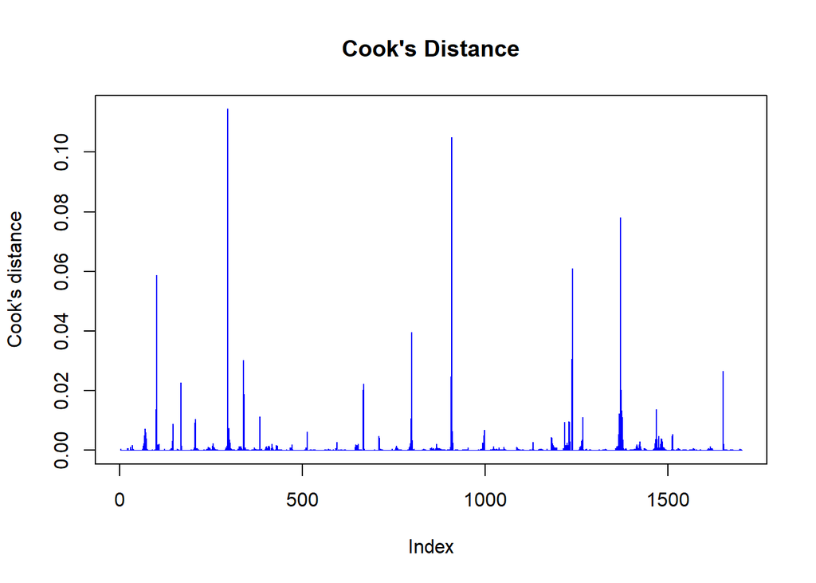

```r
cooks_distances <- cooks.distance(model1)

plot(cooks_distances, pch=20, type="h", ylab="Cook's distance",main="Cook's Distance", col=ifelse(cooks_distances > 1, "red", "blue"))
abline(h=1, col="black", lty=2)
```

```r
outliers <- which(cooks_distances > 1)

if(length(outliers) > 0) {
  text(outliers, cooks_distances[outliers], labels=outliers, pos=4, cex=0.7, col="red")
  cat("There are outliers: ", outliers, "\n")
} else {
  cat("There are no outliers based on Cook's distance threshold of 1.\n")
}
```

```
## There are no outliers based on Cook's distance threshold of 1.
```

(4).[5 points] **Detecting Multicollinearity Using Variance Inflation Factors (VIF)**

The effects that multicollinearity can have on our regression analyses and subsequent conclusions, how can we tell if multicollinearity is present in our data? A variance inflation factor exists for each of the predictors in a multiple regression model. For example, the variance inflation factor for the estimated regression coefficient $\beta_j$—denoted $VIF_j$ —is just the factor by which the variance of $\beta_j$ is “inflated” by the existence of correlation among the predictor variables in the model.

A VIF of $1$ means that there is no correlation among the $j$th predictor and the remaining predictor variables, and hence the variance of $\beta_j$ is not inflated at all. The general rule of thumb is that VIFs exceeding $4$ warrant further investigation, while VIFs exceeding $10$ are signs of serious multicollinearity requiring correction. For more information, see https://search.r-project.org/CRAN/refmans/usdm/html/vif.html.

Calculate the VIF of each predictor (use model1). Using a threshold of $\max(10, \frac{1}{1-R^2})$ what conclusions can you make regarding multicollinearity?

```r
vif_values <- vif(model1)
print(vif_values)
```

```
##                   GVIF Df GVIF^(1/(2*Df))
## Model.Year   11.158497  1        3.340434
## Type          3.285619  3        1.219278
## MPG           7.387342  1        2.717967
## Weight       11.380489  1        3.373498
## Horsepower   11.459304  1        3.385159
## Acceleration  7.680964  1        2.771455
```

```r
r_squared <- summary(model1)$r.squared
print(r_squared)
```

```
## [1] 0.9398608
```

```r
threshold <- max(10, 1/(1 - r_squared))
high_vif_indices <- which(vif_values[, "GVIF"] > threshold)

high_vif_names <- rownames(vif_values)[high_vif_indices]

if (length(high_vif_names) > 0) {
  cat("Predictors with VIF exceeding the threshold, indicating potential multicollinearity:\n")
  print(high_vif_names)
} else {
  cat("No evidence of multicollinearity based on the given threshold.")
}
```

```
## No evidence of multicollinearity based on the given threshold.
```

But in General, a GVIF (or VIF for non-factor variables) greater than 10 suggests that the predictor variable is highly collinear with other predictors in our model, which can lead to issues with model interpretation and reliability of the coefficient estimates. In our case, **Weight**, **Horsepower** and **Model.Year** would be identified by this filter as having GVIF values above 10, indicating potentially problematic multicollinearity.

Also **Acceleration** and **MPG** has a GVIF greater than 4, which warrants further investigation.

# Question 4 [16 points]

(1). Using the GermanCredit data set german.credit (Download the dataset from http://archive.ics.uci.edu/ml/datasets/Statlog+%28German+Credit+Data%29 and read the description), use logistic regression to find a good predictive model for whether credit applicants are good credit risks or not. Show your model (factors used and their coefficients), the output, and the quality of fit. You can use the glm function in R. To get a logistic regression (logit) model on data where the response is either zero or one, use family=binomial in your glm function call. Steps including:

a.[2 points] load the dataset

```
Answer:
```

```r
german_credit <- read.table("german.data", header = FALSE, sep = "", fill = TRUE)
head(german_credit)
```

```
##    V1 V2  V3  V4   V5  V6  V7 V8  V9  V10 V11  V12 V13  V14  V15 V16  V17 V18
## 1 A11  6 A34 A43 1169 A65 A75  4 A93 A101   4 A121  67 A143 A152   2 A173   1
## 2 A12 48 A32 A43 5951 A61 A73  2 A92 A101   2 A121  22 A143 A152   1 A173   1
## 3 A14 12 A34 A46 2096 A61 A74  2 A93 A101   3 A121  49 A143 A152   1 A172   2
## 4 A11 42 A32 A42 7882 A61 A74  2 A93 A103   4 A122  45 A143 A153   1 A173   2
## 5 A11 24 A33 A40 4870 A61 A73  3 A93 A101   4 A124  53 A143 A153   2 A173   2
## 6 A14 36 A32 A46 9055 A65 A73  2 A93 A101   4 A124  35 A143 A153   1 A172   2
##    V19  V20 V21
## 1 A192 A201   1
## 2 A191 A201   2
## 3 A191 A201   1
## 4 A191 A201   1
## 5 A191 A201   2
## 6 A192 A201   1
```

b.[4 points] explore the dataset, including summary of dataset, types of predictors, if there are categorical predictors, convert the predictors to factors.

```
Answer:
```

```r
summary(german_credit)
```

```
##       V1                  V2            V3                 V4
##  Length:1000        Min.   : 4.0   Length:1000        Length:1000
##  Class :character   1st Qu.:12.0   Class :character   Class :character
##  Mode  :character   Median :18.0   Mode  :character   Mode  :character
##                     Mean   :20.9
##                     3rd Qu.:24.0
##                     Max.   :72.0
##        V5             V6                 V7                  V8
##  Min.   :  250   Length:1000        Length:1000        Min.   :1.000
##  1st Qu.: 1366   Class :character   Class :character   1st Qu.:2.000
##  Median : 2320   Mode  :character   Mode  :character   Median :3.000
##  Mean   : 3271                                         Mean   :2.973
##  3rd Qu.: 3972                                         3rd Qu.:4.000
##  Max.   :18424                                         Max.   :4.000
##       V9                V10                 V11            V12
##  Length:1000        Length:1000        Min.   :1.000   Length:1000
##  Class :character   Class :character   1st Qu.:2.000   Class :character
##  Mode  :character   Mode  :character   Median :3.000   Mode  :character
##                                        Mean   :2.845
##                                        3rd Qu.:4.000
##                                        Max.   :4.000
##       V13            V14                V15                 V16
##  Min.   :19.00   Length:1000        Length:1000        Min.   :1.000
##  1st Qu.:27.00   Class :character   Class :character   1st Qu.:1.000
##  Median :33.00   Mode  :character   Mode  :character   Median :1.000
##  Mean   :35.55                                         Mean   :1.407
##  3rd Qu.:42.00                                         3rd Qu.:2.000
##  Max.   :75.00                                         Max.   :4.000
##      V17                 V18            V19                V20
##  Length:1000        Min.   :1.000   Length:1000        Length:1000
##  Class :character   1st Qu.:1.000   Class :character   Class :character
##  Mode  :character   Median :1.000   Mode  :character   Mode  :character
##                     Mean   :1.155
##                     3rd Qu.:1.000
##                     Max.   :2.000
##       V21
##  Min.   :1.0
##  1st Qu.:1.0
##  Median :1.0
##  Mean   :1.3
##  3rd Qu.:2.0
##  Max.   :2.0
```

```r
sapply(german_credit, class)
```

```
##          V1          V2          V3          V4          V5          V6
## "character"   "integer" "character" "character"   "integer" "character"
##          V7          V8          V9         V10         V11         V12
## "character"   "integer" "character" "character"   "integer" "character"
##         V13         V14         V15         V16         V17         V18
##   "integer" "character" "character"   "integer" "character"   "integer"
##         V19         V20         V21
## "character" "character"   "integer"
```

```r
categorical_columns <- c("V1", "V3", "V4", "V6", "V7", "V9", "V10", "V12", "V14", "V15", "V17", "V19", "V20")
german_credit[categorical_columns] <- lapply(german_credit[categorical_columns], factor)
head(german_credit)
```

```
##    V1 V2  V3  V4   V5  V6  V7 V8  V9  V10 V11  V12 V13  V14  V15 V16  V17 V18
## 1 A11  6 A34 A43 1169 A65 A75  4 A93 A101   4 A121  67 A143 A152   2 A173   1
## 2 A12 48 A32 A43 5951 A61 A73  2 A92 A101   2 A121  22 A143 A152   1 A173   1
## 3 A14 12 A34 A46 2096 A61 A74  2 A93 A101   3 A121  49 A143 A152   1 A172   2
## 4 A11 42 A32 A42 7882 A61 A74  2 A93 A103   4 A122  45 A143 A153   1 A173   2
## 5 A11 24 A33 A40 4870 A61 A73  3 A93 A101   4 A124  53 A143 A153   2 A173   2
## 6 A14 36 A32 A46 9055 A65 A73  2 A93 A101   4 A124  35 A143 A153   1 A172   2
##    V19  V20 V21
## 1 A192 A201   1
## 2 A191 A201   2
## 3 A191 A201   1
## 4 A191 A201   1
## 5 A191 A201   2
## 6 A192 A201   1
```

c.[2 points] Column V21 represents the target, 1 = Good, 2 = Bad, convert value the values to 0 and 1, respectively.

```
Answer:
```

```r
german_credit$V21 <- german_credit$V21 - 1
table(german_credit$V21)
```

```
##
##   0   1
## 700 300
```

d.[2 points] split the dataset to taining and test dataset with 90% and 10% of the data points, respectively.

```
Answer:
```

```r
set.seed(123)
training_size <- floor(0.9 * nrow(german_credit))
training_indices <- sample(1:nrow(german_credit), training_size)
training_data <- german_credit[training_indices, ]
test_data <- german_credit[-training_indices, ]
```

e.[3 points] use the training dataset to get a logistic regression (logit) model on data where the response is either zero or one, use family=binomial in your glm function call.

```
Answer:
```

```r
glm_model <- glm(V21 ~ ., data = training_data, family = binomial(link = "logit"))
summary(glm_model)
```

```
##
## Call:
## glm(formula = V21 ~ ., family = binomial(link = "logit"), data = training_data)
##
## Coefficients:
##               Estimate Std. Error z value Pr(>|z|)
## (Intercept) -1.917e-02  1.183e+00  -0.016 0.987074
## V1A12       -3.695e-01  2.326e-01  -1.589 0.112109
## V1A13       -9.616e-01  3.850e-01  -2.497 0.012514 *
## V1A14       -1.733e+00  2.478e-01  -6.992 2.71e-12 ***
## V2           2.934e-02  9.775e-03   3.001 0.002690 **
## V3A31        2.586e-01  5.831e-01   0.444 0.657366
## V3A32       -6.742e-01  4.595e-01  -1.467 0.142289
## V3A33       -7.987e-01  4.995e-01  -1.599 0.109803
## V3A34       -1.365e+00  4.628e-01  -2.950 0.003179 **
## V4A41       -1.569e+00  3.916e-01  -4.008 6.12e-05 ***
## V4A410      -1.619e+00  8.619e-01  -1.879 0.060311 .
## V4A42       -7.934e-01  2.804e-01  -2.830 0.004657 **
## V4A43       -8.644e-01  2.652e-01  -3.260 0.001115 **
## V4A44        3.993e-02  8.209e-01   0.049 0.961207
## V4A45        5.813e-02  6.030e-01   0.096 0.923197
## V4A46       -2.251e-01  4.231e-01  -0.532 0.594736
## V4A48       -2.077e+00  1.298e+00  -1.600 0.109540
## V4A49       -8.363e-01  3.551e-01  -2.355 0.018505 *
## V5           1.355e-04  4.669e-05   2.903 0.003700 **
## V6A62       -4.701e-01  3.074e-01  -1.530 0.126119
## V6A63       -3.594e-01  4.081e-01  -0.881 0.378553
## V6A64       -1.347e+00  5.340e-01  -2.522 0.011656 *
## V6A65       -9.795e-01  2.861e-01  -3.423 0.000618 ***
## V7A72       -2.944e-02  4.612e-01  -0.064 0.949112
## V7A73       -1.495e-01  4.455e-01  -0.336 0.737190
## V7A74       -9.106e-01  4.797e-01  -1.898 0.057662 .
## V7A75       -3.903e-01  4.479e-01  -0.871 0.383516
## V8           4.103e-01  9.484e-02   4.327 1.51e-05 ***
## V9A92       -2.937e-01  4.151e-01  -0.708 0.479195
## V9A93       -9.543e-01  4.113e-01  -2.320 0.020342 *
## V9A94       -2.619e-01  4.908e-01  -0.534 0.593616
## V10A102      3.632e-01  4.391e-01   0.827 0.408117
## V10A103     -1.026e+00  4.564e-01  -2.249 0.024536 *
## V11          1.706e-03  9.231e-02   0.018 0.985253
```

[output cut: 10 more lines]

```
## V17A173      4.552e-01  7.156e-01   0.636 0.524682
## V17A174      1.752e-01  7.158e-01   0.245 0.806650
## V18          4.267e-01  2.623e-01   1.627 0.103766
## V19A192     -2.798e-01  2.145e-01  -1.304 0.192089
## V20A202     -1.538e+00  7.191e-01  -2.138 0.032482 *
## ---
## Signif. codes:  0 '***' 0.001 '**' 0.01 '*' 0.05 '.' 0.1 ' ' 1
##
## (Dispersion parameter for binomial family taken to be 1)
##
##     Null deviance: 1090.95  on 899  degrees of freedom
## Residual deviance:  792.88  on 851  degrees of freedom
## AIC: 890.88
##
## Number of Fisher Scoring iterations: 5
```

f.[4 points] use the model to make prediction on the the training dataset, and test dataset, give the confusion matrices and accuracy for each dataset.

```
Answer:
```

```r
probs_train <- predict(glm_model, type = "response", newdata = training_data)
preds_train <- ifelse(probs_train > 0.5, 1, 0)
conf_matrix_train <- table(Predicted = preds_train, Actual = training_data$V21)
accuracy_train <- sum(diag(conf_matrix_train)) / sum(conf_matrix_train)
print("Confusion Matrix for Training Data:")
```

```
## [1] "Confusion Matrix for Training Data:"
```

```r
print(conf_matrix_train)
```

```
##          Actual
## Predicted   0   1
##         0 566 122
##         1  69 143
```

```r
print(paste("Accuracy for Training Data:", accuracy_train))
```

```
## [1] "Accuracy for Training Data: 0.787777777777778"
```

```r
probs_test <- predict(glm_model, type = "response", newdata = test_data)
preds_test <- ifelse(probs_test > 0.5, 1, 0)
conf_matrix_test <- table(Predicted = preds_test, Actual = test_data$V21)
accuracy_test <- sum(diag(conf_matrix_test)) / sum(conf_matrix_test)
print("Confusion Matrix for Test Data:")
```

```
## [1] "Confusion Matrix for Test Data:"
```

```r
print(conf_matrix_test)
```

```
##          Actual
## Predicted  0  1
##         0 58 17
##         1  7 18
```

```r
print(paste("Accuracy for Test Data:", accuracy_test))
```

```
## [1] "Accuracy for Test Data: 0.76"
```

(2). [4 points] Because the model gives a result between $0$ and $1$, it requires setting a threshold probability to separate between “good” and “bad” answers. In this data set, they estimate that incorrectly identifying a bad customer as good, is $5$ times worse than incorrectly classifying a good customer as bad. Determine a good threshold probability based on your model (please demonstrate your reasoning.)

```
Answer:
```

```r
cost_fp = 5
cost_fn = 1
thresholds <- seq(0, 1, by = 0.01)
costs <- data.frame(Threshold = thresholds, TotalCost = NA)
actual_factor <- factor(test_data$V21, levels = c(0, 1))
for (i in seq_along(thresholds)) {
  threshold <- thresholds[i]
  predicted_factor <- factor(ifelse(probs_test > threshold, 1, 0), levels = c(0, 1))
  conf_matrix <- table(Predicted = predicted_factor, Actual = actual_factor)
  fp <- ifelse(is.na(conf_matrix["1", "0"]), 0, conf_matrix["1", "0"])
  fn <- ifelse(is.na(conf_matrix["0", "1"]), 0, conf_matrix["0", "1"])
  total_cost <- (fp * cost_fp) + (fn * cost_fn)
  costs$TotalCost[i] <- total_cost
}
optimal_threshold <- costs[which.min(costs$TotalCost),]

print(paste("Good threshold Probablity:", optimal_threshold$Threshold))
```

```
## [1] "Good threshold Probablity: 0.91"
```

```r
print(paste("Minimum total cost:", optimal_threshold$TotalCost))
```

```
## [1] "Minimum total cost: 31"
```

Determining a good threshold probability, especially when dealing with asymmetric mis-classification costs, involves balancing the trade-offs between different types of prediction errors. Let’s break down the key components of the reasoning:

**Cost Calculation Across Thresholds:**

The code iteratively calculates the total misclassification cost across a range of possible threshold probabilities (from 0 to 1, in increments of 0.01). For each threshold:

- Predictions are categorized as “good” or “bad” based on whether they exceed the threshold.
- A confusion matrix is generated to count false positives (fp) and false negatives (fn).
- The total cost is computed as the sum of the costs of all misclassifications, weighted by the specified costs (cost_fp for false positives and cost_fn for false negatives). Here the total minimum cost is **31**

**Optimal Threshold Selection:**

**Summary**

This approach aligns the decision-making process closely with the financial implications of each type of error, providing a data-driven method to inform threshold selection for binary classification in contexts where errors have differing consequences. It exemplifies a principled way to incorporate domain knowledge—here, the relative costs of different types of misclassifications—into model evaluation and application.

# Question 5 [28 points]

In this problem, you will develop a model to predict whether a given car gets high or low gas mileage based on the `Auto` data set.

(1).[2 points] Create a binary variable, `mpg01`, that contains a $1$ if mpg contains a value above its median, and a $0$ if mpg contains a value below its median. You can compute the median using the `median()` function. Note you may find it helpful to use the data.frame() function to create a single data set containing both `mpg01` and the other `Auto` variables.

```
Answer:
```

```r
data(Auto)
head(Auto,5)
```

```
##   mpg cylinders displacement horsepower weight acceleration year origin
## 1  18         8          307        130   3504         12.0   70      1
## 2  15         8          350        165   3693         11.5   70      1
## 3  18         8          318        150   3436         11.0   70      1
## 4  16         8          304        150   3433         12.0   70      1
## 5  17         8          302        140   3449         10.5   70      1
##                        name
## 1 chevrolet chevelle malibu
## 2         buick skylark 320
## 3        plymouth satellite
## 4             amc rebel sst
## 5               ford torino
```

```r
mpg01 <- rep(0, length(Auto$mpg))
mpg01[Auto$mpg > median(Auto$mpg)] <- 1
Auto <- data.frame(Auto, mpg01)
head(Auto,5)
```

```
##   mpg cylinders displacement horsepower weight acceleration year origin
## 1  18         8          307        130   3504         12.0   70      1
## 2  15         8          350        165   3693         11.5   70      1
## 3  18         8          318        150   3436         11.0   70      1
## 4  16         8          304        150   3433         12.0   70      1
## 5  17         8          302        140   3449         10.5   70      1
##                        name mpg01
## 1 chevrolet chevelle malibu     0
## 2         buick skylark 320     0
## 3        plymouth satellite     0
## 4             amc rebel sst     0
## 5               ford torino     0
```

(2).[4 points] Explore the data graphically in order to investigate the association between `mpg01` and the other features. Which of the other features seem most likely to be useful in predicting `mpg01`? Scatterplots and boxplots may be useful tools to answer this question. Describe your findings.

```
Answer:
```

```r
cor(Auto[, -9])
```

```
##                     mpg  cylinders displacement horsepower     weight
## mpg           1.0000000 -0.7776175   -0.8051269 -0.7784268 -0.8322442
## cylinders    -0.7776175  1.0000000    0.9508233  0.8429834  0.8975273
## displacement -0.8051269  0.9508233    1.0000000  0.8972570  0.9329944
## horsepower   -0.7784268  0.8429834    0.8972570  1.0000000  0.8645377
## weight       -0.8322442  0.8975273    0.9329944  0.8645377  1.0000000
## acceleration  0.4233285 -0.5046834   -0.5438005 -0.6891955 -0.4168392
## year          0.5805410 -0.3456474   -0.3698552 -0.4163615 -0.3091199
## origin        0.5652088 -0.5689316   -0.6145351 -0.4551715 -0.5850054
## mpg01         0.8369392 -0.7591939   -0.7534766 -0.6670526 -0.7577566
##              acceleration       year     origin      mpg01
## mpg             0.4233285  0.5805410  0.5652088  0.8369392
## cylinders      -0.5046834 -0.3456474 -0.5689316 -0.7591939
## displacement   -0.5438005 -0.3698552 -0.6145351 -0.7534766
## horsepower     -0.6891955 -0.4163615 -0.4551715 -0.6670526
## weight         -0.4168392 -0.3091199 -0.5850054 -0.7577566
## acceleration    1.0000000  0.2903161  0.2127458  0.3468215
## year            0.2903161  1.0000000  0.1815277  0.4299042
## origin          0.2127458  0.1815277  1.0000000  0.5136984
## mpg01           0.3468215  0.4299042  0.5136984  1.0000000
```

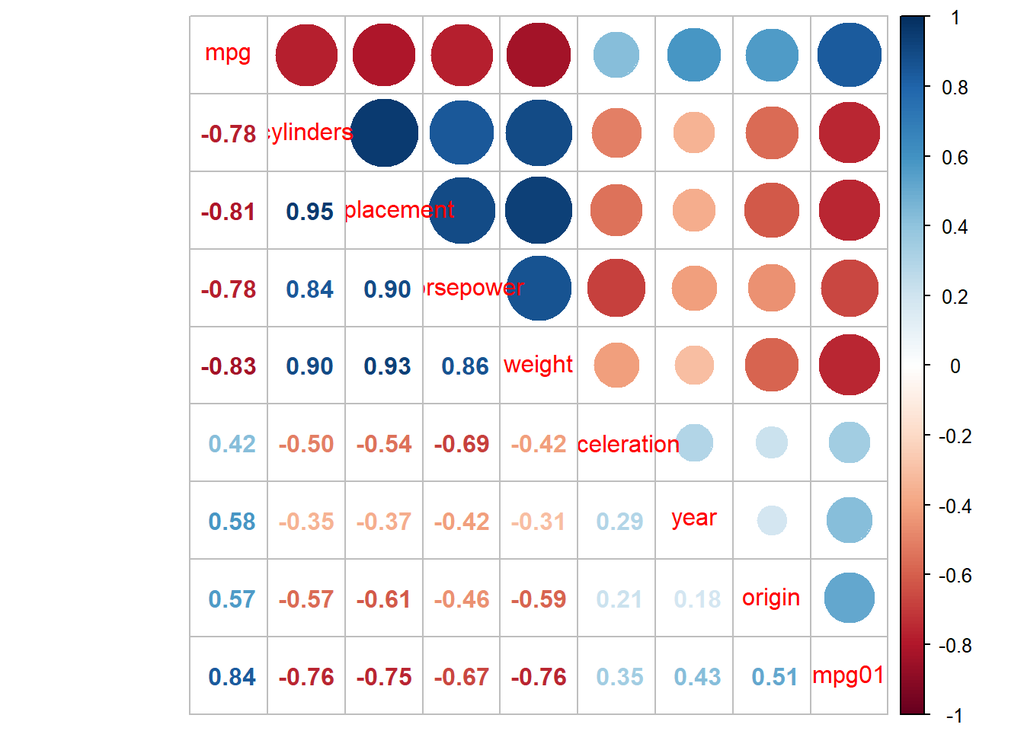

```r
corrplot::corrplot.mixed(cor(Auto[, -9]), upper="circle")
```

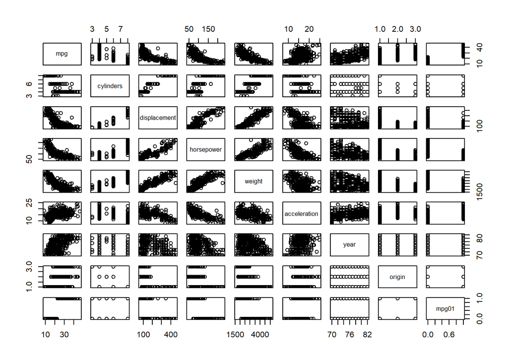

```r
pairs(Auto[, -9])
```

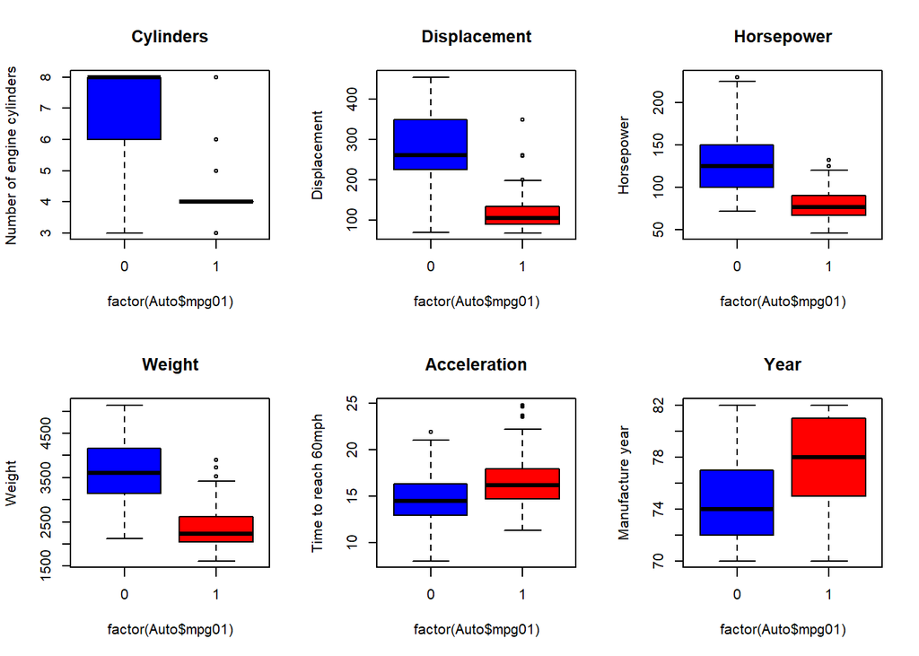

```r
par(mfrow = c(2, 3))
boxplot(Auto$cylinders ~ factor(Auto$mpg01), ylab = "Number of engine cylinders",
        col=c("blue", "red"), main="Cylinders")
boxplot(Auto$displacement ~ factor(Auto$mpg01), ylab = "Displacement",
        col=c("blue", "red"), main="Displacement")
boxplot(Auto$horsepower ~ factor(Auto$mpg01), ylab = "Horsepower",
        col=c("blue", "red"), main="Horsepower")
boxplot(Auto$weight ~ factor(Auto$mpg01), ylab = "Weight",
        col=c("blue", "red"), main="Weight")
boxplot(Auto$acceleration ~ factor(Auto$mpg01), ylab = "Time to reach 60mph",
        col=c("blue", "red"), main="Acceleration")
boxplot(Auto$year ~ factor(Auto$mpg01), ylab = "Manufacture year",
        col=c("blue", "red"), main="Year")
```

The above correlation matrix and graphs indicate that there exists some association between **mpg01** and **cylinders**, **weight**, **displacement** and **horsepower** and they are useful in predicting **mpg01**

(3).[2 points] Split the data into a training set and a test set.

```
Answer:
```

```r
set.seed(123)
train <- sample(1:dim(Auto)[1], dim(Auto)[1]*.7, rep=FALSE)
test <- -train
training_data<- Auto[train, ]
testing_data= Auto[test, ]
mpg01.test <- mpg01[test]
```

(4).[3 points] Perform LDA on the training data in order to predict `mpg01` using the variables that seemed most associated with `mpg01` in (2). What is the test error of the model obtained?

```
Answer:
```

```r
lda_model <- lda(mpg01 ~ cylinders + weight + displacement + horsepower, data = training_data)
lda_model
```

```
## Call:
## lda(mpg01 ~ cylinders + weight + displacement + horsepower, data = training_data)
##
## Prior probabilities of groups:
##         0         1
## 0.4963504 0.5036496
##
## Group means:
##   cylinders   weight displacement horsepower
## 0  6.786765 3641.022     275.2941  130.96324
## 1  4.188406 2314.000     114.5290   78.00725
##
## Coefficients of linear discriminants:
##                        LD1
## cylinders    -0.3974647924
## weight       -0.0009670704
## displacement -0.0029615583
## horsepower    0.0049004106
```

```r
lda_pred = predict(lda_model, testing_data)
names(lda_pred)
```

```
## [1] "class"     "posterior" "x"
```

```r
pred.lda <- predict(lda_model, testing_data)
table(pred.lda$class, mpg01.test)
```

```
##    mpg01.test
##      0  1
##   0 50  3
##   1 10 55
```

```r
mean(pred.lda$class != mpg01.test)
```

```
## [1] 0.1101695
```

The test error of LDA model obtained is **11.02%**

(5).[3 points] Perform QDA on the training data in order to predict `mpg01` using the variables that seemed most associated with `mpg01` in (2). What is the test error of the model obtained?

```
Answer:
```

```r
qda_model = qda(mpg01 ~ cylinders + horsepower + weight + acceleration, data=training_data)
qda_model
```

```
## Call:
## qda(mpg01 ~ cylinders + horsepower + weight + acceleration, data = training_data)
##
## Prior probabilities of groups:
##         0         1
## 0.4963504 0.5036496
##
## Group means:
##   cylinders horsepower   weight acceleration
## 0  6.786765  130.96324 3641.022     14.55588
## 1  4.188406   78.00725 2314.000     16.55072
```

```r
qda.class=predict(qda_model, testing_data)$class
table(qda.class, testing_data$mpg01)
```

```
##
## qda.class  0  1
##         0 53  4
##         1  7 54
```

```r
mean(qda.class != testing_data$mpg01)
```

```
## [1] 0.09322034
```

The test error of QDA model obtained is **9.32%**

(6). [3 points] Perform logistic regression on the training data in order to predict `mpg01` using the variables that seemed most associated with `mpg01` in (2). What is the test error of the model obtained?

```
Answer:
```

```r
glm_model <- glm(mpg01 ~ cylinders + weight + displacement + horsepower, data = training_data, family = binomial)
summary(glm_model)
```

```
##
## Call:
## glm(formula = mpg01 ~ cylinders + weight + displacement + horsepower,
##     family = binomial, data = training_data)
##
## Coefficients:
##                Estimate Std. Error z value Pr(>|z|)
## (Intercept)  11.8103006  2.0819718   5.673 1.41e-08 ***
## cylinders     0.1869071  0.3972245   0.471  0.63797
## weight       -0.0020251  0.0008573  -2.362  0.01817 *
## displacement -0.0164493  0.0095899  -1.715  0.08629 .
## horsepower   -0.0443408  0.0172072  -2.577  0.00997 **
## ---
## Signif. codes:  0 '***' 0.001 '**' 0.01 '*' 0.05 '.' 0.1 ' ' 1
##
## (Dispersion parameter for binomial family taken to be 1)
##
##     Null deviance: 379.83  on 273  degrees of freedom
## Residual deviance: 138.27  on 269  degrees of freedom
## AIC: 148.27
##
## Number of Fisher Scoring iterations: 7
```

```r
probs <- predict(glm_model, testing_data, type = "response")
pred.glm <- rep(0, length(probs))
pred.glm[probs > 0.5] <- 1
table(pred.glm, mpg01.test)
```

```
##         mpg01.test
## pred.glm  0  1
##        0 53  6
##        1  7 52
```

```r
mean(pred.glm != mpg01.test)
```

```
## [1] 0.1101695
```

The test error of Logistic regression model obtained is **11.02%**

(7). [3 points] Perform naive Bayes on the training data in order to predict `mpg01` using the variables that seemed most associated with `mpg01` in (2). What is the test error of the model obtained?

```
Answer:
```

```r
library(e1071)
nb_model <- naiveBayes(mpg01 ~ cylinders + weight + displacement + horsepower, data = training_data)
probs_nb <- predict(nb_model, newdata = testing_data, type = "raw")
preds_nb <- ifelse(probs_nb[,2] > 0.5, 1, 0)
table(Predicted = preds_nb, Actual = testing_data$mpg01)
```

```
##          Actual
## Predicted  0  1
##         0 52  4
##         1  8 54
```

```r
mean(preds_nb != testing_data$mpg01)
```

```
## [1] 0.1016949
```

The test error of NaiveBayes model obtained is **10.17%**

(8). [5 points] Perform KNN on the training data in order to predict `mpg01` using the variables that seemed most associated with `mpg01` in (2). What is the test error of the model obtained? Which value of K seems to perform the best on this data set?

```
Answer:
```

```r
str(Auto)
```

```
## 'data.frame':    392 obs. of  10 variables:
##  $ mpg         : num  18 15 18 16 17 15 14 14 14 15 ...
##  $ cylinders   : int  8 8 8 8 8 8 8 8 8 8 ...
##  $ displacement: num  307 350 318 304 302 429 454 440 455 390 ...
##  $ horsepower  : int  130 165 150 150 140 198 220 215 225 190 ...
##  $ weight      : int  3504 3693 3436 3433 3449 4341 4354 4312 4425 3850 ...
##  $ acceleration: num  12 11.5 11 12 10.5 10 9 8.5 10 8.5 ...
##  $ year        : int  70 70 70 70 70 70 70 70 70 70 ...
##  $ origin      : int  1 1 1 1 1 1 1 1 1 1 ...
##  $ name        : Factor w/ 304 levels "amc ambassador brougham",..: 49 36 231 14 161 141 54 223 241 2 ...
##  $ mpg01       : num  0 0 0 0 0 0 0 0 0 0 ...
```

```r
data = scale(Auto[,-c(9,10)])
set.seed(123)
train <- sample(1:dim(Auto)[1], 392*.7, rep=FALSE)
test <- -train
training_data = data[train,c("cylinders","horsepower","weight","acceleration")]
testing_data = data[test, c("cylinders", "horsepower","weight","acceleration")]
train.mpg01 = Auto$mpg01[train]
test.mpg01= Auto$mpg01[test]
set.seed(123)
knn_pred_y = knn(training_data, testing_data, train.mpg01, k = 4)
table(knn_pred_y, test.mpg01)
```

```
##           test.mpg01
## knn_pred_y  0  1
##          0 54  5
##          1  6 53
```

```r
mean(knn_pred_y != test.mpg01)
```

```
## [1] 0.09322034
```

```r
knn_pred_y = knn(training_data, testing_data, train.mpg01, k = 6)
table(knn_pred_y, test.mpg01)
```

```
##           test.mpg01
## knn_pred_y  0  1
##          0 54  4
##          1  6 54
```

```r
mean(knn_pred_y != test.mpg01)
```

```
## [1] 0.08474576
```

```r
knn_pred_y = knn(training_data, testing_data, train.mpg01, k = 5)
table(knn_pred_y, test.mpg01)
```

```
##           test.mpg01
## knn_pred_y  0  1
##          0 55  3
##          1  5 55
```

```r
mean(knn_pred_y != test.mpg01)
```

```
## [1] 0.06779661
```

The test error of KNN algorithm is **6.78%** at k=5. We have arrived at k=5 after testing different values of k.

(9).[3 points] Compare the above models, which models do you think is the best, why?

```
Answer:
```

Comparing the models based on the test errors, the **K-Nearest Neighbors (KNN) algorithm with k=5** has the lowest test error rate at 6.78%. This makes it the best-performing model, according to this metric.

**KNN is the best model based on below Assumptions:**

**Lower Test Error:** The primary criterion for model comparison here is the test error rate, where a lower rate indicates a model that generalizes better to unseen data. KNN’s test error is the lowest, suggesting it is the most accurate at predictions in this specific case.

**Flexibility and Non-Linearity:** KNN inherently can capture non-linear relationships between features and the outcome without needing a specific model form. This flexibility might allow it to perform better if the true relationship in the data is complex or non-linear.

**Considerations Beyond Test Error:**

While KNN shows the best performance in terms of test error, there are additional factors one might consider when choosing a model for practical application:

**Interpretability:** Models like logistic regression, LDA (Linear Discriminant Analysis), and even Naive Bayes tend to be more interpretable than KNN or QDA (Quadratic Discriminant Analysis). If understanding how input variables affect the outcome is important, these models might still be considered valuable.

**Computational Efficiency:** KNN can be computationally intensive, especially with large datasets, since it requires computing distances from the query instance to all training instances. If prediction speed is a critical factor, logistic regression or LDA might be preferred due to their simpler and faster prediction mechanisms.

**Overfitting Risks:** While not directly indicated by the test error rates, models like QDA can be more prone to overfitting, especially with small datasets or datasets with a large number of features relative to the number of observations. Regularization techniques or model selection criteria are essential to mitigate this risk.

**Model Assumptions:** Each model comes with its own set of assumptions (e.g., LDA assumes equal covariance matrices across groups, logistic regression assumes a logit-linear relationship between the predictor variables and the log odds of the outcome). The best-performing model in terms of test error might still be a poor choice if its fundamental assumptions are violated by the data.

**Conclusion:**

Based solely on the provided test error rates, **KNN with k=5 is the best model for this dataset**. However, final model selection should also consider the context in which the model will be used, including factors like interpretability, computational resources, and the specific objectives of the analysis. Balancing accuracy with these considerations ensures not only a statistically sound model but also one that aligns with the practical needs of the application.